# Economic Data 2025 - Labs

Week 9

*Aims*: Data cleaning, applying functions by groups, libraries and data formats.

*Libraries*: `ggplot2`, `dplyr`.

Your country depends on the timing of your lab session:

- Monday: Greece
- Tuesday: Finland
- Wednesday: Spain
- Thursday: Slovenia
- Friday: France

## Part 1

In this exercise we will plot the Gini index in 2019 for as many countries as possible. To solve the exercise, go through the following steps.

- Download data on the Gini Index from the [World Bank](https://data.worldbank.org/), load it into R, and clean the dataset.
- Construct the plots below for your assigned country. **Hint**: To go from wide to long you can use some version of `gather(year, gini, 2:65)` from the `dplyr` library.

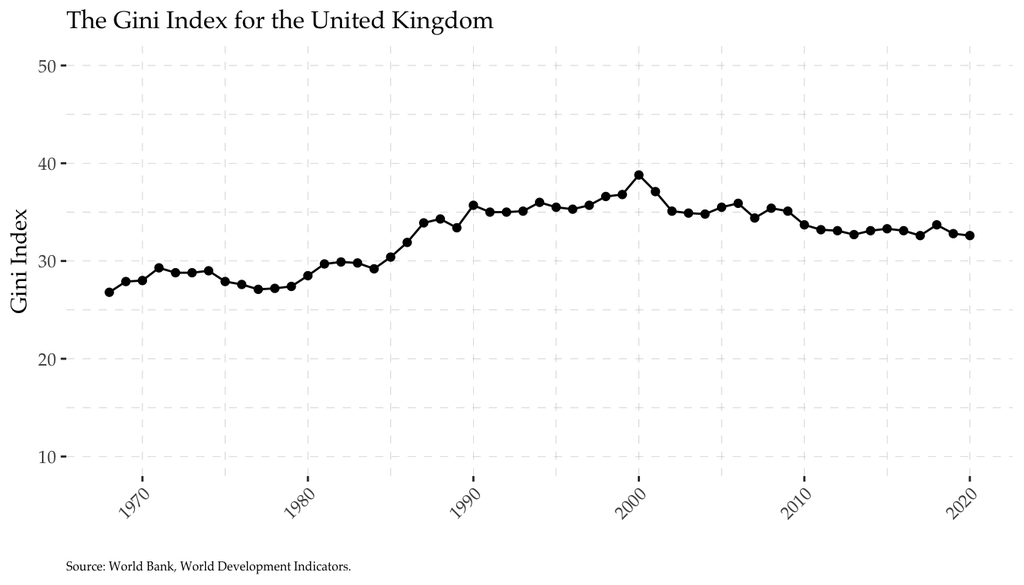

- Construct the plot below for all the countries with available data on the Gini coefficient for 2019. **Hint**: The commands `ggplot(df, aes(x=reorder(country, gini), y=gini))`, `geom_linerange(aes(ymin=0, ymax=gini, alpha = 0.8))` and `coord_flip()` might be useful.

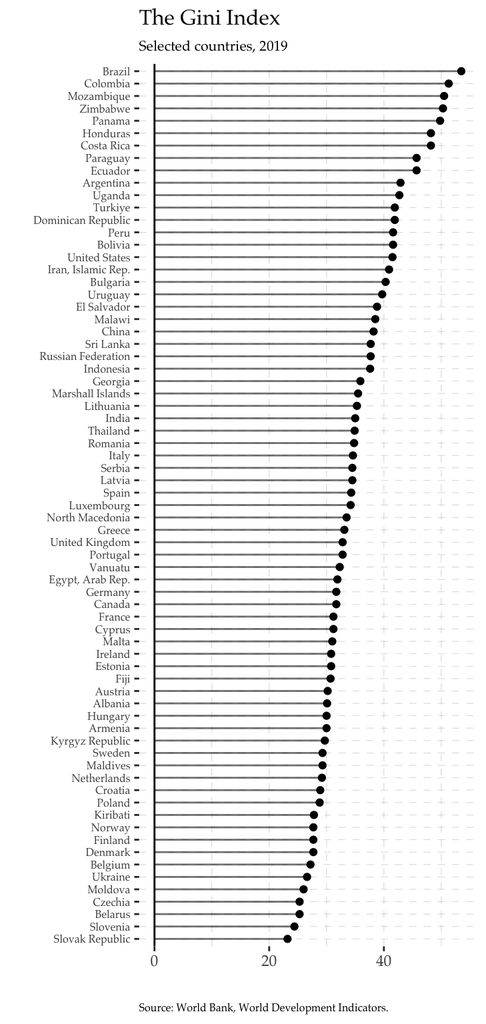

## Part 2

In this exercise, we will consider the change in the Gini coefficients for the countries in our dataset.

- Create a new dataset where you keep all the years. Clean the dataset and keep the columns with the years and country names.
- Change the shape of the dataset from wide to long.
- Construct the chart below. Let the vertical line denote the change for your assigned country.

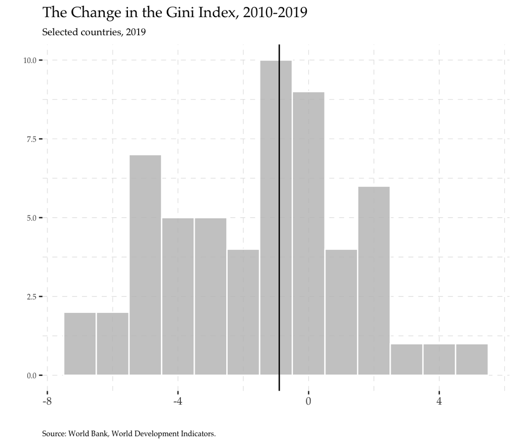